# Time Series Analysis Spring 2023

12. Extensions of GARCH Models

Maciej Świtała

18/05/2022

# Packages and data

Lets load all needed packages

```r
library(tidyverse)
library(xts)
library(tseries)# e.g. jarque.bera.test()
library(car) # e.g. durbinWatsonTest()
library(fBasics) # e.g. basicStats()
library(fGarch) # e.g. garchFit()
library(rugarch) # e.g. ugarchfit()
```

If necessary, install the new package we will use today:

```r
install.packages("rugarch")
```

A gentle introduction to the `rugarch` package and a detailed description of all models available in it are presented in this vignette: http://cran.r-project.org/web/packages/rugarch/vignettes/Introduction_to_the_rugarch_package.pdf

Additional materials:

- http://www.unstarched.net/r-examples/rugarch/a-short-introduction-to-the-rugarch-package/
- Tsay (2015)

Let’s also load the workspace from `labs11`:

```r
load("objects/workspace_labs11.RData")
```

Let’s load additional functions which help easily compare ICs for GARCH models:

```r
source("functions/compare_ICs_GARCH.R")
source("functions/compare_ICs_ugarchfit.R")
```

We should remind ourselves the comparison of models estimated last time:

```r
compare_ICs_GARCH(c("k.arch1", "k.arch1a", "k.arch5", "k.arch10",
                    "k.garch11", "k.garch21", "k.ar5garch21",
                    "k.ar5garch11", "k.ar5arch10"))
```

```
## $ICs
##         AIC       BIC       SIC      HQIC        model
## 1 -6.118407 -6.114405 -6.118408 -6.117003      k.arch1
## 2 -6.117666 -6.114998 -6.117666 -6.116729     k.arch1a
## 3 -6.432811 -6.423473 -6.432815 -6.429533      k.arch5
## 4 -6.476821 -6.460813 -6.476833 -6.471203     k.arch10
## 5 -6.480545 -6.475209 -6.480547 -6.478673    k.garch11
## 6 -6.482037 -6.475368 -6.482040 -6.479697    k.garch21
## 7 -6.488726 -6.475386 -6.488734 -6.484044 k.ar5garch21
## 8 -6.487056 -6.475050 -6.487063 -6.482842 k.ar5garch11
## 9 -6.483155 -6.460478 -6.483180 -6.475196  k.ar5arch10
##
## $which.min
##  AIC  BIC  SIC HQIC
##    7    7    7    7
```

The AR(5)-GARCH(2,1) was best fitting to the data.

# GARCH extensions

## The EGARCH model

Let’s examine whether conditional variance reacts asymmetrically to the news arriving to the market. Below estimation of the AR(5)-EGARCH(2,1) model.

Advantages of the `ugarchfit()` from the `rugarch` package:

- in some applications more flexible than garchFit
- allows also for extensions
- allows to add restrictions on parameters

Here, first we have to define a model specification:

```r
spec <- ugarchspec(# variance equation
                   variance.model = list(model = "eGARCH",
                                         garchOrder = c(2, 1)),
                   # sGARCH would stand for standard GARCH model
                   # mean equation - lets use AR(5) as previously
                   mean.model = list(armaOrder = c(5, 0),
                                     include.mean = TRUE),
                   # assumed distribution of errors
                   distribution.model = "norm")
```

The `ugarchfit()` function doesn’t accept missing values.

```r
any(is.na(SP500$r))
```

```
## [1] FALSE
```

If there were any, in case of returns we can replace any missings with 0 (if no return, then price did not change).

```r
SP500$r[is.na(SP500$r)] <- 0
```

and estimate the model:

```r
k.ar5egarch21 <- ugarchfit(spec = spec,
                           data = SP500$r)
```

Now, we can see the results:

```r
k.ar5egarch21
```

```
##
## *---------------------------------*
## *          GARCH Model Fit        *
## *---------------------------------*
##
## Conditional Variance Dynamics
## -----------------------------------
## GARCH Model  : eGARCH(2,1)
## Mean Model   : ARFIMA(5,0,0)
## Distribution : norm
##
## Optimal Parameters
## ------------------------------------
##         Estimate  Std. Error      t value Pr(>|t|)
## mu      0.000275    0.000098      2.79289 0.005224
## ar1    -0.070690    0.013595     -5.19972 0.000000
## ar2    -0.022836    0.014923     -1.53026 0.125952
## ar3     0.003846    0.014793      0.25996 0.794896
## ar4    -0.001822    0.014587     -0.12494 0.900572
## ar5    -0.022364    0.014206     -1.57423 0.115434
## omega  -0.257221    0.002440   -105.43958 0.000000
## alpha1 -0.230727    0.021022    -10.97544 0.000000
## alpha2  0.089088    0.021415      4.16011 0.000032
## beta1   0.972205    0.000008 115734.21301 0.000000
## gamma1 -0.013752    0.010546     -1.30400 0.192233
## gamma2  0.163164    0.014945     10.91785 0.000000
##
## Robust Standard Errors:
##         Estimate  Std. Error     t value Pr(>|t|)
## mu      0.000275    0.000108     2.54728 0.010857
## ar1    -0.070690    0.012359    -5.71987 0.000000
## ar2    -0.022836    0.016340    -1.39753 0.162255
## ar3     0.003846    0.014120     0.27234 0.785358
## ar4    -0.001822    0.015977    -0.11407 0.909182
## ar5    -0.022364    0.014696    -1.52181 0.128058
## omega  -0.257221    0.003248   -79.19042 0.000000
## alpha1 -0.230727    0.035103    -6.57278 0.000000
## alpha2  0.089088    0.035288     2.52459 0.011583
## beta1   0.972205    0.000013 74583.41245 0.000000
## gamma1 -0.013752    0.017348    -0.79270 0.427950
```

[output cut: 61 more lines]

```
## Negative Sign Bias  0.9313 0.3517
## Positive Sign Bias  0.3450 0.7301
## Joint Effect        1.5319 0.6749
##
##
## Adjusted Pearson Goodness-of-Fit Test:
## ------------------------------------
##   group statistic p-value(g-1)
## 1    20     141.4    9.920e-21
## 2    30     156.3    2.128e-19
## 3    40     169.2    3.849e-18
## 4    50     174.4    5.927e-16
##
##
## Elapsed time : 1.354303
```

The AR2 to AR5 are not statistically significant!

Let’s remove them and estimate a simpler model AR(1)-EGARCH(2,1):

```r
spec <- ugarchspec(# variance equation
                   variance.model = list(model = "eGARCH",
                                         garchOrder = c(2, 1)),
                   # sGARCH would stand for standard GARCH model
                   # mean equation - lets use AR(1) as previously
                   mean.model = list(armaOrder = c(1, 0),
                                     include.mean = TRUE),
                   # assumed distribution of errors
                   distribution.model = "norm")
```

Now, we estimate the model:

```r
k.ar1egarch21 <- ugarchfit(spec = spec,
                           data = SP500$r)
```

An finally we can examine the results:

```r
k.ar1egarch21
```

```
##
## *---------------------------------*
## *          GARCH Model Fit        *
## *---------------------------------*
##
## Conditional Variance Dynamics
## -----------------------------------
## GARCH Model  : eGARCH(2,1)
## Mean Model   : ARFIMA(1,0,0)
## Distribution : norm
##
## Optimal Parameters
## ------------------------------------
##         Estimate  Std. Error    t value Pr(>|t|)
## mu      0.000253    0.000084     2.9925 0.002767
## ar1    -0.069830    0.011705    -5.9660 0.000000
## omega  -0.253557    0.002322  -109.1865 0.000000
## alpha1 -0.232174    0.018893   -12.2888 0.000000
## alpha2  0.086821    0.018531     4.6851 0.000003
## beta1   0.972608    0.000013 73159.3474 0.000000
## gamma1 -0.014033    0.007497    -1.8718 0.061237
## gamma2  0.160256    0.010544    15.1986 0.000000
##
## Robust Standard Errors:
##         Estimate  Std. Error    t value Pr(>|t|)
## mu      0.000253    0.000084     2.9971 0.002725
## ar1    -0.069830    0.010536    -6.6275 0.000000
## omega  -0.253557    0.003020   -83.9679 0.000000
## alpha1 -0.232174    0.027746    -8.3678 0.000000
## alpha2  0.086821    0.027473     3.1602 0.001577
## beta1   0.972608    0.000023 41501.5506 0.000000
## gamma1 -0.014033    0.011123    -1.2616 0.207098
## gamma2  0.160256    0.014001    11.4460 0.000000
##
## LogLikelihood : 15911.6
##
## Information Criteria
## ------------------------------------
##
## Akaike       -6.5380
```

[output cut: 49 more lines]

```
## Negative Sign Bias  0.8920 0.3725
## Positive Sign Bias  0.4249 0.6710
## Joint Effect        1.5991 0.6596
##
##
## Adjusted Pearson Goodness-of-Fit Test:
## ------------------------------------
##   group statistic p-value(g-1)
## 1    20     137.2    6.142e-20
## 2    30     146.8    1.062e-17
## 3    40     165.0    1.970e-17
## 4    50     180.0    7.293e-17
##
##
## Elapsed time : 0.522701
```

Now (almost) all the parameters are statistically significant.

Coefficient `alpha1` is the asymmetry term of EGARCH model (measuring the leverage effect). For further details see the package vignette (eq. 14, page 19, https://cran.r-project.org/web/packages/rugarch/vignettes/Introduction_to_the_rugarch_package.pdf)

It is negative and significant, so the asymmetry is found!

No further autocorrelation in R and R^2, no further ARCH effects.

The Nyblom stability test verifies the null that all parameters or each parameter separately are stable over time (no structural breaks in the model). If test statistic is greater than the critical value, the null is rejected.

So here we reject the stability jointly (4.6282 > 2.11), but cannot reject for any parameter (stat < 0.47).

The Sign Bias Test verifies the null hypothesis if there is still some asymmetric reaction of variance of residuals to shocks. If null not rejected - the asymmetry has been captured correctly in the estimated model. The model does not require higher order.

Again, like in the case of `fGarch` class objects, we can use the `plot()` function to plot automatically several parts of the results. Calling the `plot()` function with the objects of class `uGARCHfit` will enter the interactive mode which offers a selection of, this time, 12 plots:

```
 1:   Series with 2 Conditional SD Superimposed
 2:   Series with 1% VaR Limits
 3:   Conditional SD (vs |returns|)
 4:   ACF of Observations
 5:   ACF of Squared Observations
 6:   ACF of Absolute Observations
 7:   Cross Correlation
 8:   Empirical Density of Standardized Residuals
 9:   QQ-Plot of Standardized Residuals
10:   ACF of Standardized Residuals
11:   ACF of Squared Standardized Residuals
12:   News-Impact Curve
```

First, let’s see all of them:

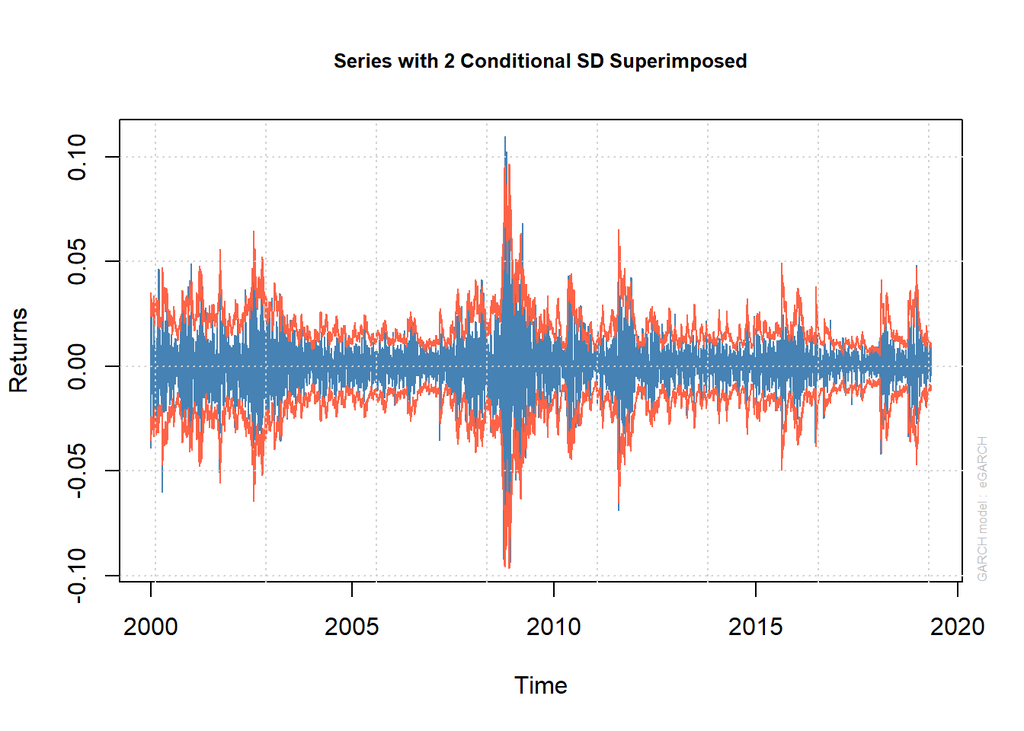

```
##
## please wait...calculating quantiles...
```

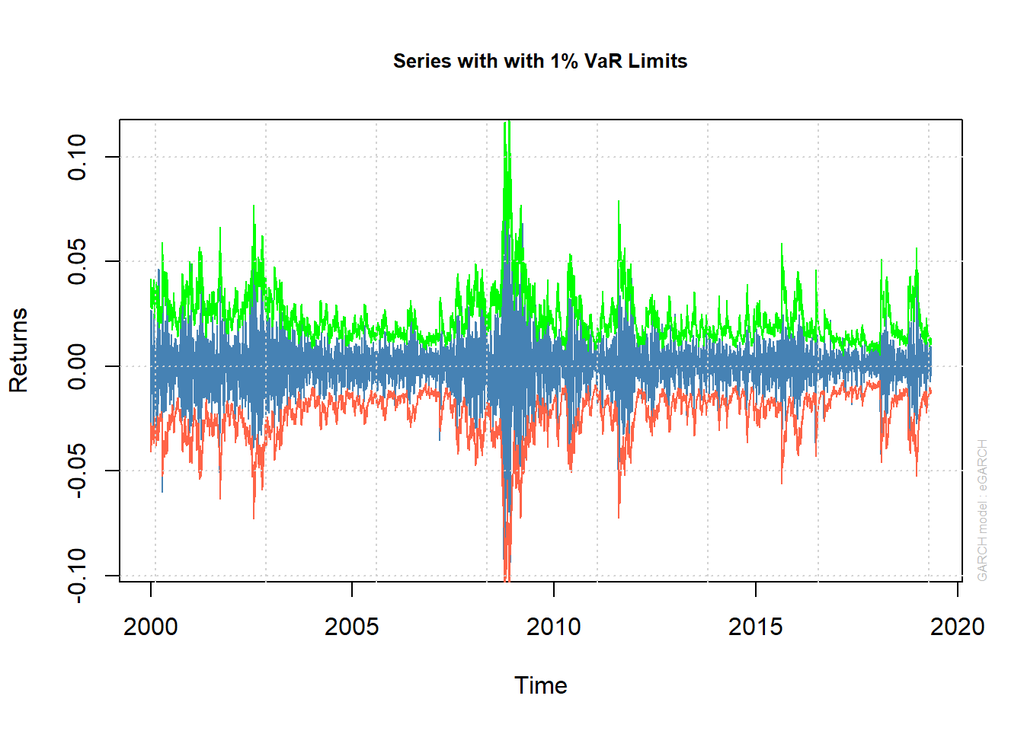

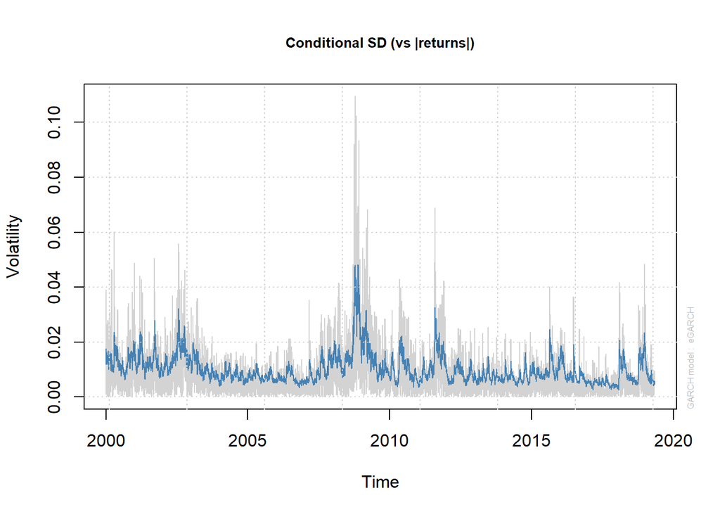

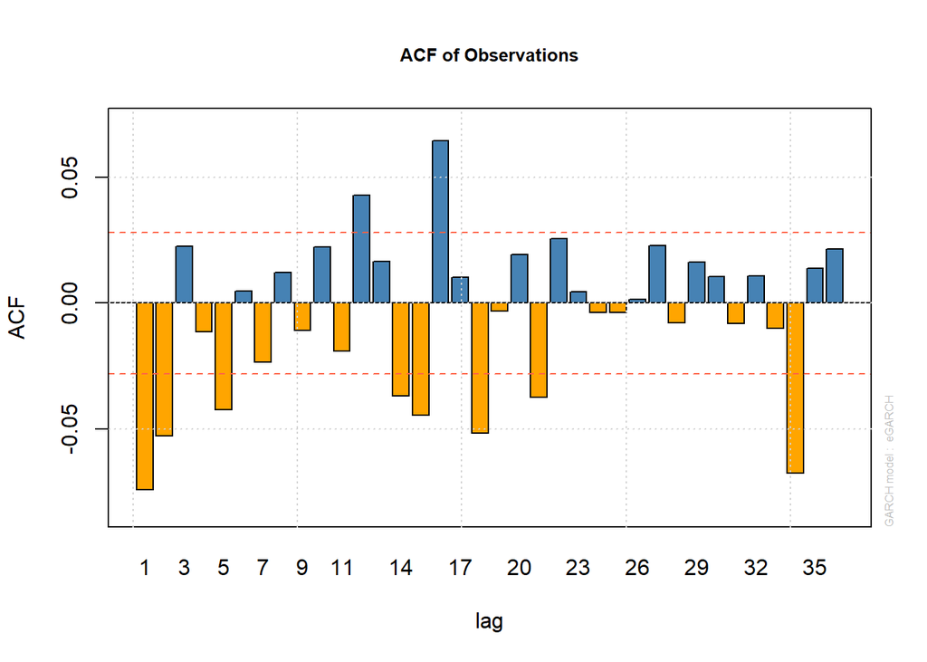

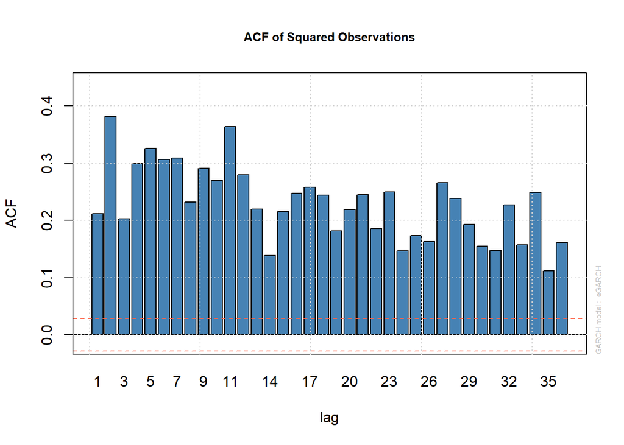

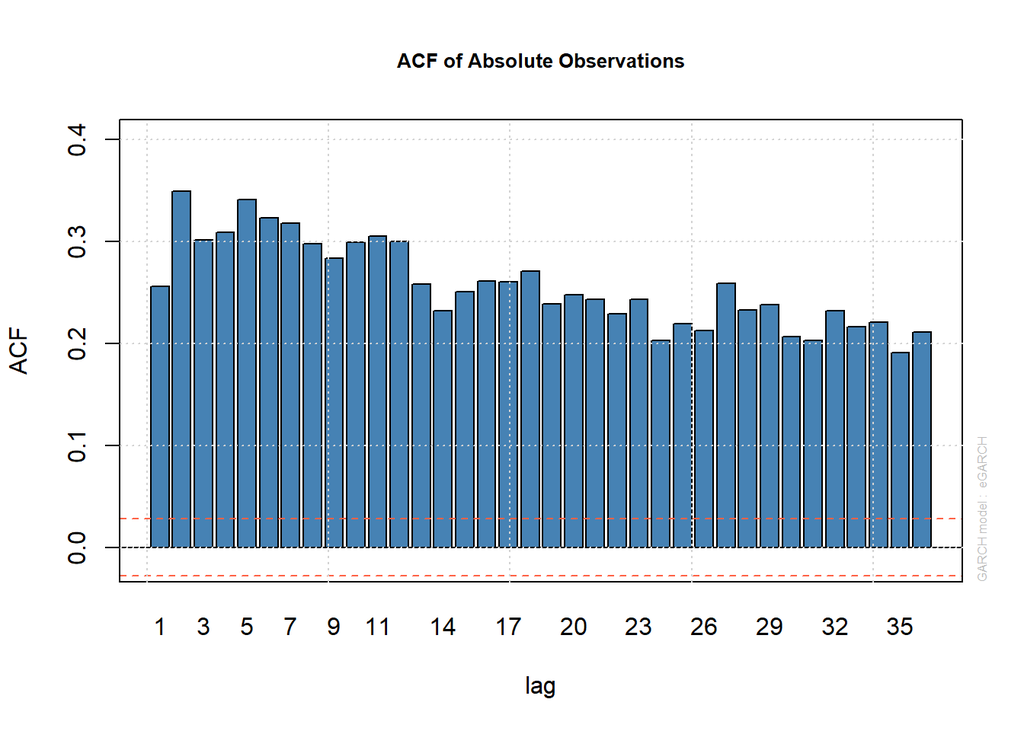

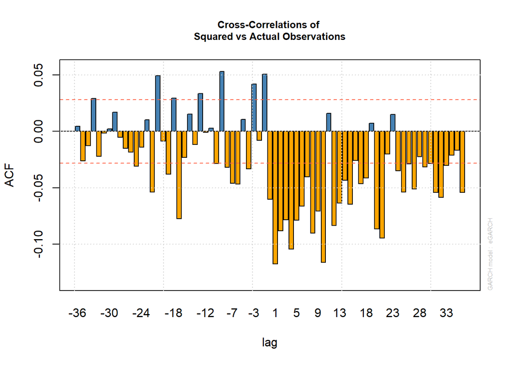

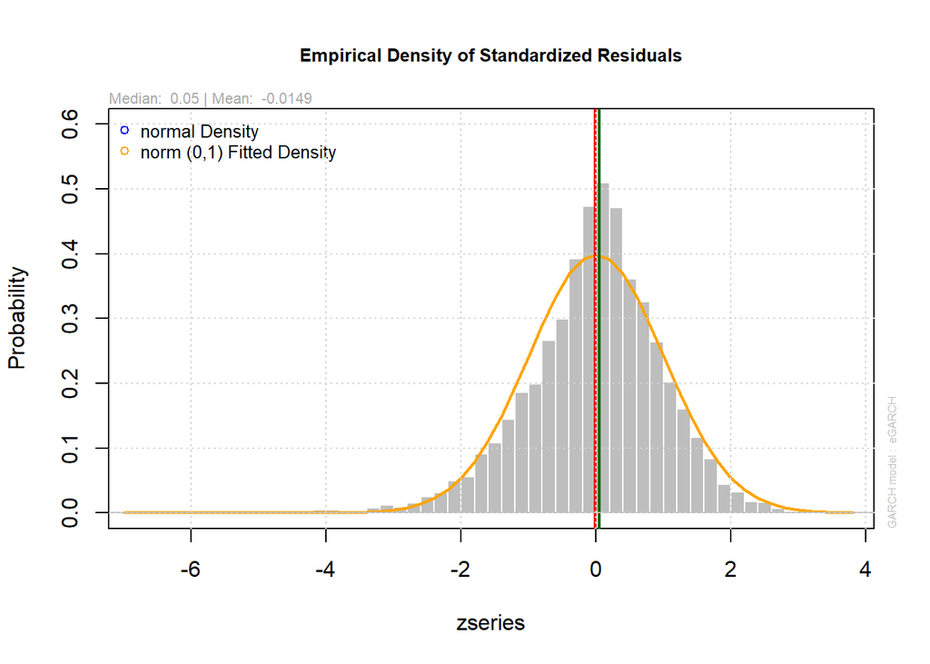

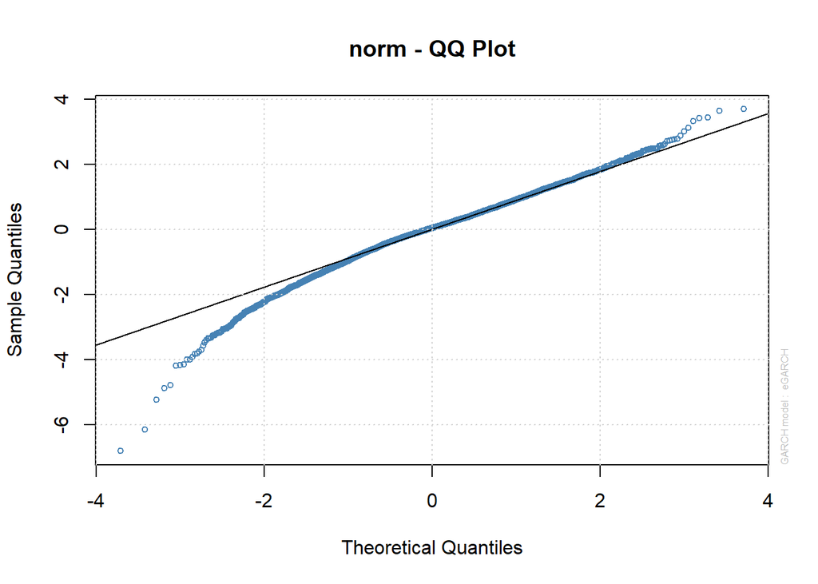

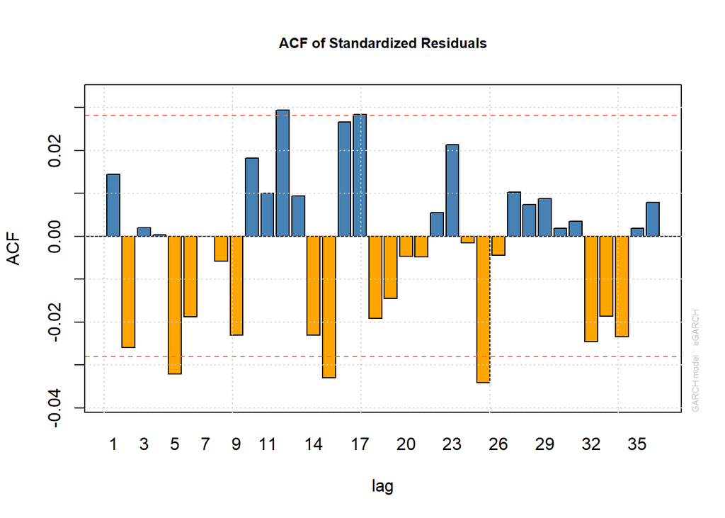

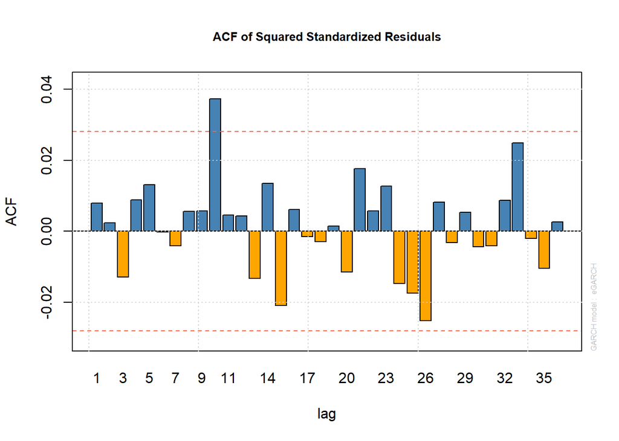

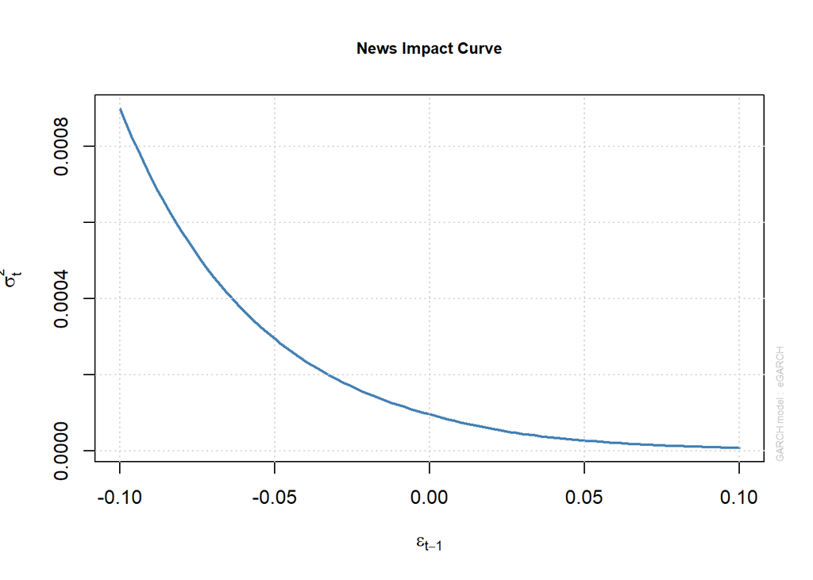

```r
for (i in 1:12) plot(k.ar1egarch21, which = i)
```

If you call `plot(kk.ar1egarch21)` in the console - remember to quit by pressing ESC before you continue!

For now, most interesting for us are:

```
# 3:  Conditional SD (vs |returns|)
# 11: ACF of Squared Standardized Residuals
# 12: News-Impact curve
```

Hence, let’s call the plot() function again:

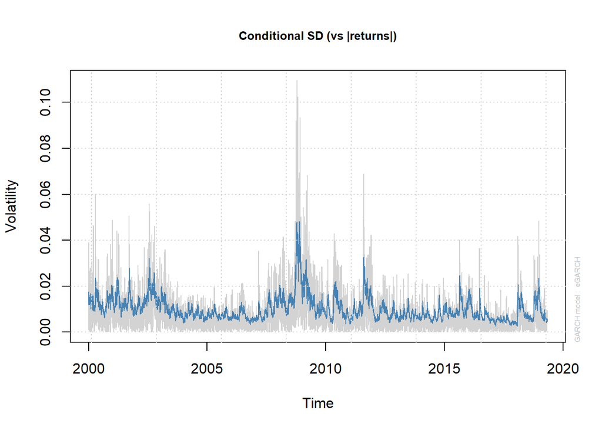

```r
plot(k.ar1egarch21, which = 3)
```

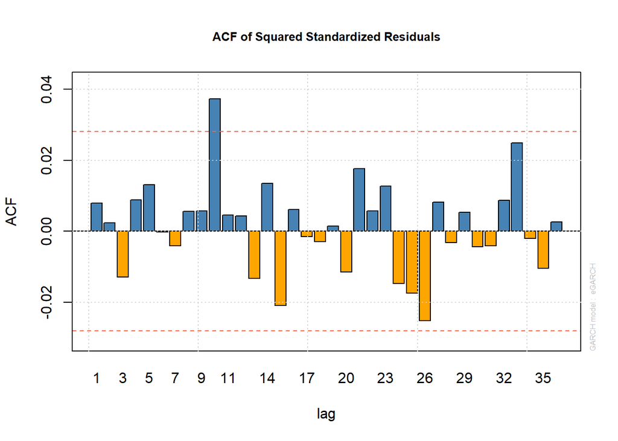

```r
plot(k.ar1egarch21, which = 11)
```

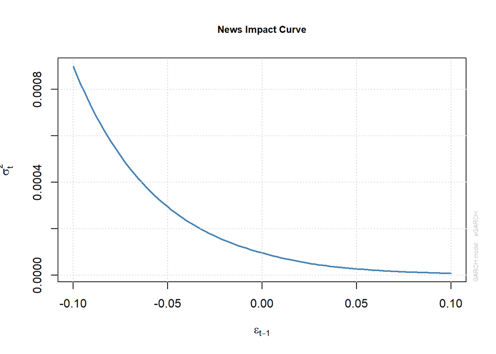

```r
plot(k.ar1egarch21, which = 12)
```

## The GARCH-in-Mean model

Let’s first define a model specification:

```r
spec <- ugarchspec(# variance equation
                   variance.model = list(model = "sGARCH",
                                         # sGARCH = standard GARCH
                                         garchOrder = c(2, 1)),
                   # mean equation - lets turn on the intercept term
                   mean.model = list(armaOrder = c(1, 0),
                                     include.mean = TRUE,
                       # we add an element to the mean equation,
                       # which can be either stdev (archpow 1)
                       # or var (archpow=2)
                                     archm = TRUE, archpow = 1),
                   # assumed distribution of errors
                   distribution.model = "norm")
```

Then, we can estimate the model:

```r
k.ar1garchm21 <- ugarchfit(spec = spec,
                           data = SP500$r)
```

Let’s examine the results:

```r
k.ar1garchm21
```

```
##
## *---------------------------------*
## *          GARCH Model Fit        *
## *---------------------------------*
##
## Conditional Variance Dynamics
## -----------------------------------
## GARCH Model  : sGARCH(2,1)
## Mean Model   : ARFIMA(1,0,0)
## Distribution : norm
##
## Optimal Parameters
## ------------------------------------
##         Estimate  Std. Error   t value Pr(>|t|)
## mu     -0.000027    0.000317 -0.086726 0.930889
## ar1    -0.059639    0.014917 -3.998148 0.000064
## archm   0.076105    0.038467  1.978431 0.047880
## omega   0.000002    0.000001  2.747668 0.006002
## alpha1  0.070270    0.013736  5.115758 0.000000
## alpha2  0.058307    0.018010  3.237420 0.001206
## beta1   0.853000    0.013991 60.968619 0.000000
##
## Robust Standard Errors:
##         Estimate  Std. Error   t value Pr(>|t|)
## mu     -0.000027    0.000385 -0.071331 0.943134
## ar1    -0.059639    0.013348 -4.467934 0.000008
## archm   0.076105    0.046909  1.622417 0.104714
## omega   0.000002    0.000005  0.456764 0.647841
## alpha1  0.070270    0.024415  2.878205 0.003999
## alpha2  0.058307    0.049432  1.179558 0.238176
## beta1   0.853000    0.062170 13.720500 0.000000
##
## LogLikelihood : 15782.56
##
## Information Criteria
## ------------------------------------
##
## Akaike       -6.4853
## Bayes        -6.4760
## Shibata      -6.4853
```

[output cut: 46 more lines]

```
## Negative Sign Bias  0.1868 0.85183469660
## Positive Sign Bias  2.3662 0.01801299992  **
## Joint Effect       36.4456 0.00000006028 ***
##
##
## Adjusted Pearson Goodness-of-Fit Test:
## ------------------------------------
##   group statistic p-value(g-1)
## 1    20     182.2    1.116e-28
## 2    30     203.3    4.352e-28
## 3    40     235.8    5.661e-30
## 4    50     259.3    2.166e-30
##
##
## Elapsed time : 0.9056091
```

The `mu` parameter is not significant - lets remove it from the model.

```r
spec <-
  ugarchspec(# variance equation
    variance.model = list(model = "sGARCH",
                          # sGARCH = standard GARCH
                          garchOrder = c(2, 1)),
    # mean equation - lets turn on the intercept term
    mean.model = list(armaOrder = c(1, 0),
                      include.mean = FALSE,
                      # we add an element to the mean equation,
                      # which can be either stdev (archpow 1)
                      # or var (archpow=2)
                      archm = TRUE, archpow = 1),
    # assumed distribution of errors
    distribution.model = "norm")
```

Model estimation:

```r
k.ar1garchm21 <- ugarchfit(spec = spec,
                           data = SP500$r)
```

Model summary:

```r
k.ar1garchm21
```

```
##
## *---------------------------------*
## *          GARCH Model Fit        *
## *---------------------------------*
##
## Conditional Variance Dynamics
## -----------------------------------
## GARCH Model  : sGARCH(2,1)
## Mean Model   : ARFIMA(1,0,0)
## Distribution : norm
##
## Optimal Parameters
## ------------------------------------
##         Estimate  Std. Error  t value Pr(>|t|)
## ar1    -0.059866    0.014909  -4.0156 0.000059
## archm   0.072984    0.013041   5.5963 0.000000
## omega   0.000002    0.000001   2.7973 0.005153
## alpha1  0.069989    0.013707   5.1059 0.000000
## alpha2  0.058775    0.017899   3.2837 0.001024
## beta1   0.852817    0.013755  61.9986 0.000000
##
## Robust Standard Errors:
##         Estimate  Std. Error  t value Pr(>|t|)
## ar1    -0.059866    0.013388 -4.47180 0.000008
## archm   0.072984    0.012173  5.99554 0.000000
## omega   0.000002    0.000005  0.46902 0.639057
## alpha1  0.069989    0.024363  2.87277 0.004069
## alpha2  0.058775    0.047904  1.22692 0.219852
## beta1   0.852817    0.059933 14.22960 0.000000
##
## LogLikelihood : 15782.56
##
## Information Criteria
## ------------------------------------
##
## Akaike       -6.4857
## Bayes        -6.4777
## Shibata      -6.4857
## Hannan-Quinn -6.4829
##
```

[output cut: 43 more lines]

```
## Negative Sign Bias  0.1885 0.85045967890
## Positive Sign Bias  2.3425 0.01919528641  **
## Joint Effect       36.6442 0.00000005472 ***
##
##
## Adjusted Pearson Goodness-of-Fit Test:
## ------------------------------------
##   group statistic p-value(g-1)
## 1    20     180.9    2.089e-28
## 2    30     204.8    2.362e-28
## 3    40     234.7    9.075e-30
## 4    50     260.3    1.421e-30
##
##
## Elapsed time : 1.051446
```

Is the estimate of the archm parameter significantly positive?

## The GARCH-t model

Let’s see whether conditional distribution of the error term can be better described by the t-Student distribution.

Let’s first define a model specification:

```r
spec <- ugarchspec(# variance equation
                   variance.model = list(model = "sGARCH",
                                         garchOrder = c(2, 1)),
                   # mean equation
                   mean.model = list(armaOrder = c(1, 0),
                                     include.mean = TRUE),
                   # assumed distribution of errors
                   distribution.model = "std") # std = t-Student
```

Then, we estimate the model:

```r
k.ar1garcht21 <- ugarchfit(spec = spec,
                           data = SP500$r)
```

Model summary:

```r
k.ar1garcht21
```

```
##
## *---------------------------------*
## *          GARCH Model Fit        *
## *---------------------------------*
##
## Conditional Variance Dynamics
## -----------------------------------
## GARCH Model  : sGARCH(2,1)
## Mean Model   : ARFIMA(1,0,0)
## Distribution : std
##
## Optimal Parameters
## ------------------------------------
##         Estimate  Std. Error  t value Pr(>|t|)
## mu      0.000677    0.000096   7.0361 0.000000
## ar1    -0.062219    0.013723  -4.5338 0.000006
## omega   0.000002    0.000001   1.1010 0.270899
## alpha1  0.044391    0.015526   2.8592 0.004247
## alpha2  0.091058    0.023508   3.8735 0.000107
## beta1   0.861204    0.025189  34.1895 0.000000
## shape   6.158153    0.322781  19.0784 0.000000
##
## Robust Standard Errors:
##         Estimate  Std. Error  t value Pr(>|t|)
## mu      0.000677    0.000133  5.10949 0.000000
## ar1    -0.062219    0.011812 -5.26734 0.000000
## omega   0.000002    0.000008  0.18891 0.850163
## alpha1  0.044391    0.019112  2.32269 0.020196
## alpha2  0.091058    0.182120  0.49999 0.617082
## beta1   0.861204    0.159604  5.39588 0.000000
## shape   6.158153    2.693541  2.28627 0.022239
##
## LogLikelihood : 15891.59
##
## Information Criteria
## ------------------------------------
##
## Akaike       -6.5301
## Bayes        -6.5208
## Shibata      -6.5302
```

[output cut: 46 more lines]

```
## Negative Sign Bias   0.625 0.532025780
## Positive Sign Bias   2.219 0.026507380  **
## Joint Effect        35.346 0.000000103 ***
##
##
## Adjusted Pearson Goodness-of-Fit Test:
## ------------------------------------
##   group statistic       p-value(g-1)
## 1    20     87.78 0.0000000000819547
## 2    30    120.56 0.0000000000003961
## 3    40    123.49 0.0000000001043576
## 4    50    135.89 0.0000000004228063
##
##
## Elapsed time : 0.5925999
```

The `shape` paramters denotes the number of degrees of freedom for the t-Student distribution. In this case it equals to 6.158.

One more thing! The conditional variance equation seems to be incomplete (see Ljung-Box Test on Standardized Squared Residuals!). On the other hand ARCH tests do NOT show any problem with the conditional variance equation.

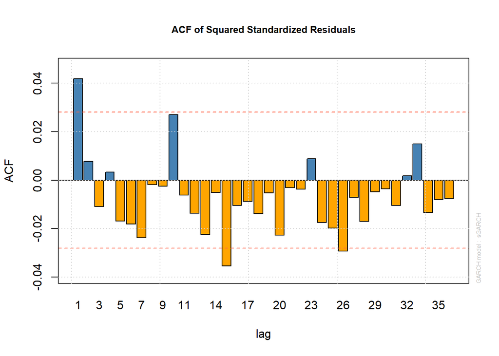

```r
plot(k.ar1garcht21, which = 11)
```

Plot 11 shows significance of 1st lag!

It is not clear if t distribution is better than normal distribution.

We will compare the information criteria later.

All the above elements of themodel can be combined into one model.

## The EGARCH in mean-t model

Let’s first define the model specification:

```r
spec <- ugarchspec(# variance equation
                   variance.model = list(model = "eGARCH",
                                         garchOrder = c(2, 1)),
                   # mean equation
                   mean.model = list(armaOrder = c(1, 0),
                                     include.mean = TRUE,
                                     archm = TRUE, archpow = 1),
                   # assumed distribution of errors
                   distribution.model = "std") # std = t-Student
```

Now, we estimate the model:

```r
k.ar1egarchmt21 <- ugarchfit(spec = spec,
                             data = SP500$r)
```

The model summary:

```r
k.ar1egarchmt21
```

```
##
## *---------------------------------*
## *          GARCH Model Fit        *
## *---------------------------------*
##
## Conditional Variance Dynamics
## -----------------------------------
## GARCH Model  : eGARCH(2,1)
## Mean Model   : ARFIMA(1,0,0)
## Distribution : std
##
## Optimal Parameters
## ------------------------------------
##         Estimate  Std. Error      t value Pr(>|t|)
## mu      0.000394    0.000220      1.78745 0.073865
## ar1    -0.062238    0.013160     -4.72925 0.000002
## archm   0.008458    0.036636      0.23088 0.817409
## omega  -0.191321    0.002905    -65.85687 0.000000
## alpha1 -0.268785    0.024341    -11.04255 0.000000
## alpha2  0.123875    0.024561      5.04351 0.000000
## beta1   0.980217    0.000001 822466.06112 0.000000
## gamma1 -0.057504    0.004473    -12.85616 0.000000
## gamma2  0.199753    0.017105     11.67836 0.000000
## shape   7.013774    0.692947     10.12166 0.000000
##
## Robust Standard Errors:
##         Estimate  Std. Error      t value Pr(>|t|)
## mu      0.000394    0.000321      1.22452 0.220756
## ar1    -0.062238    0.012396     -5.02091 0.000001
## archm   0.008458    0.056444      0.14985 0.880881
## omega  -0.191321    0.003890    -49.18367 0.000000
## alpha1 -0.268785    0.026288    -10.22447 0.000000
## alpha2  0.123875    0.028151      4.40039 0.000011
## beta1   0.980217    0.000001 732120.50270 0.000000
## gamma1 -0.057504    0.005908     -9.73294 0.000000
## gamma2  0.199753    0.023264      8.58638 0.000000
## shape   7.013774    0.806510      8.69646 0.000000
##
## LogLikelihood : 16004.65
##
```

[output cut: 55 more lines]

```
## Negative Sign Bias  1.1868 0.2354
## Positive Sign Bias  0.4248 0.6710
## Joint Effect        1.6538 0.6472
##
##
## Adjusted Pearson Goodness-of-Fit Test:
## ------------------------------------
##   group statistic   p-value(g-1)
## 1    20     76.65 0.000000006971
## 2    30     91.60 0.000000020621
## 3    40    104.43 0.000000069677
## 4    50    116.12 0.000000225496
##
##
## Elapsed time : 2.196983
```

Now it looks better! The `alpha1` and `shape` parameters are significant, while the `archm` is not.

No further extensions of the mean and conditional variance equations are needed.

Lets keep this specification as a final one. We will save its specification for later prediction as a new object:

```r
specFinal <- spec
```

Let’s also remind the results the AR(5)-GARCH(2,1) model estimated last time. We will reestimate it with the `ugarchfit()` function.

```r
spec <- ugarchspec(# variance equation
                   variance.model = list(model = "sGARCH",
                                         garchOrder = c(2, 1)),
                   mean.model = list(armaOrder = c(5, 0),
                                     include.mean = TRUE),
                   distribution.model = "norm")
k.ar5garch21 <- ugarchfit(spec = spec,
                          data = SP500$r)
```

Model summary:

```r
k.ar5garch21
```

```
##
## *---------------------------------*
## *          GARCH Model Fit        *
## *---------------------------------*
##
## Conditional Variance Dynamics
## -----------------------------------
## GARCH Model  : sGARCH(2,1)
## Mean Model   : ARFIMA(5,0,0)
## Distribution : norm
##
## Optimal Parameters
## ------------------------------------
##         Estimate  Std. Error  t value Pr(>|t|)
## mu      0.000564    0.000099  5.72492 0.000000
## ar1    -0.062179    0.014945 -4.16057 0.000032
## ar2    -0.030710    0.015535 -1.97687 0.048056
## ar3    -0.011143    0.015279 -0.72927 0.465836
## ar4    -0.010541    0.015168 -0.69499 0.487061
## ar5    -0.037986    0.015034 -2.52672 0.011513
## omega   0.000002    0.000001  2.73786 0.006184
## alpha1  0.069662    0.013700  5.08499 0.000000
## alpha2  0.058626    0.018051  3.24773 0.001163
## beta1   0.853402    0.013943 61.20777 0.000000
##
## Robust Standard Errors:
##         Estimate  Std. Error  t value Pr(>|t|)
## mu      0.000564    0.000092  6.16430 0.000000
## ar1    -0.062179    0.013416 -4.63462 0.000004
## ar2    -0.030710    0.015951 -1.92529 0.054193
## ar3    -0.011143    0.014154 -0.78724 0.431139
## ar4    -0.010541    0.016798 -0.62755 0.530297
## ar5    -0.037986    0.014194 -2.67624 0.007445
## omega   0.000002    0.000005  0.43947 0.660319
## alpha1  0.069662    0.024620  2.82952 0.004662
## alpha2  0.058626    0.052163  1.12391 0.261051
## beta1   0.853402    0.064104 13.31271 0.000000
##
## LogLikelihood : 15786.11
##
```

[output cut: 55 more lines]

```
## Negative Sign Bias  0.2412 0.80943658936
## Positive Sign Bias  2.4049 0.01621451452  **
## Joint Effect       37.5399 0.00000003537 ***
##
##
## Adjusted Pearson Goodness-of-Fit Test:
## ------------------------------------
##   group statistic p-value(g-1)
## 1    20     178.9    5.015e-28
## 2    30     201.9    8.098e-28
## 3    40     244.9    1.176e-31
## 4    50     270.7    1.985e-32
##
##
## Elapsed time : 0.6583421
```

The AR3 and AR4 paramters are not significatnt. Hence, we can fix their values at 0.

```r
spec <- ugarchspec(# variance equation
                   variance.model = list(model = "sGARCH",
                                         garchOrder = c(2, 1)),
                   mean.model = list(armaOrder = c(5,0),
                                     include.mean = TRUE),
                   distribution.model = "norm",
                   # you need to use correct parameter names
                   fixed.pars = list(ar3 = 0, ar4 = 0))
k.ar5garch21_2 <- ugarchfit(spec = spec,
                            data = SP500$r)
```

Model summary:

```r
k.ar5garch21_2
```

```
##
## *---------------------------------*
## *          GARCH Model Fit        *
## *---------------------------------*
##
## Conditional Variance Dynamics
## -----------------------------------
## GARCH Model  : sGARCH(2,1)
## Mean Model   : ARFIMA(5,0,0)
## Distribution : norm
##
## Optimal Parameters
## ------------------------------------
##         Estimate  Std. Error  t value Pr(>|t|)
## mu      0.000560    0.000100   5.5810 0.000000
## ar1    -0.061630    0.014929  -4.1283 0.000037
## ar2    -0.030291    0.015499  -1.9544 0.050648
## ar3     0.000000          NA       NA       NA
## ar4     0.000000          NA       NA       NA
## ar5    -0.037328    0.015011  -2.4867 0.012892
## omega   0.000002    0.000001   2.7496 0.005966
## alpha1  0.068999    0.013661   5.0507 0.000000
## alpha2  0.059431    0.018045   3.2935 0.000989
## beta1   0.853211    0.013929  61.2540 0.000000
##
## Robust Standard Errors:
##         Estimate  Std. Error  t value Pr(>|t|)
## mu      0.000560    0.000102  5.51401 0.000000
## ar1    -0.061630    0.014838 -4.15363 0.000033
## ar2    -0.030291    0.015698 -1.92969 0.053645
## ar3     0.000000          NA       NA       NA
## ar4     0.000000          NA       NA       NA
## ar5    -0.037328    0.014834 -2.51639 0.011856
## omega   0.000002    0.000006  0.41902 0.675203
## alpha1  0.068999    0.023116  2.98488 0.002837
## alpha2  0.059431    0.054962  1.08132 0.279556
## beta1   0.853211    0.066748 12.78264 0.000000
##
## LogLikelihood : 15785.63
##
```

[output cut: 53 more lines]

```
## Negative Sign Bias  0.3008 0.76359869190
## Positive Sign Bias  2.3889 0.01693699082  **
## Joint Effect       36.5944 0.00000005606 ***
##
##
## Adjusted Pearson Goodness-of-Fit Test:
## ------------------------------------
##   group statistic p-value(g-1)
## 1    20     181.0    1.931e-28
## 2    30     199.1    2.696e-27
## 3    40     253.0    3.813e-33
## 4    50     273.1    7.204e-33
##
##
## Elapsed time : 0.54351
```

Now, let’s compare information criteria for all models:

```r
compare_ICs_ugarchfit(c("k.ar5garch21",
                        "k.ar5garch21_2",
                        "k.ar5egarch21",
                        "k.ar1egarch21",
                        "k.ar1garchm21",
                        "k.ar1garcht21",
                        "k.ar1egarchmt21"))
```

```
## $ICs
##      Akaike     Bayes   Shibata Hannan.Quinn           model
## 1 -6.485553 -6.472213 -6.485561    -6.480871    k.ar5garch21
## 2 -6.486179 -6.475507 -6.486184    -6.482433  k.ar5garch21_2
## 3 -6.537233 -6.521226 -6.537246    -6.531615   k.ar5egarch21
## 4 -6.537964 -6.527292 -6.537969    -6.534218   k.ar1egarch21
## 5 -6.485738 -6.477734 -6.485741    -6.482929   k.ar1garchm21
## 6 -6.530149 -6.520811 -6.530153    -6.526872   k.ar1garcht21
## 7 -6.575397 -6.562058 -6.575406    -6.570715 k.ar1egarchmt21
##
## $which.min
##       Akaike        Bayes      Shibata Hannan.Quinn
##            7            7            7            7
```

All criteria indicate that AR-EGARCH-in-mean-t is the best model here.

# Predictions with GARCH models

Lets estimate a model on a shorter sample

```r
tail(SP500, 10)
```

```
##              SP500             r
## 2019-04-23 2933.68  0.0088023512
## 2019-04-24 2927.25 -0.0021941687
## 2019-04-25 2926.17 -0.0003690417
## 2019-04-26 2939.88  0.0046743503
## 2019-04-29 2943.03  0.0010709483
## 2019-04-30 2945.83  0.0009509648
## 2019-05-01 2923.73 -0.0075304460
## 2019-05-02 2917.52 -0.0021262443
## 2019-05-03 2945.64  0.0095921275
## 2019-05-06 2932.47 -0.0044810132
```

Lets put aside last 6 observations:

```r
SP500.short <- SP500["/2019-04-26",]
tail(SP500.short)
```

```
##              SP500             r
## 2019-04-18 2905.03  0.0015778468
## 2019-04-22 2907.97  0.0010115060
## 2019-04-23 2933.68  0.0088023512
## 2019-04-24 2927.25 -0.0021941687
## 2019-04-25 2926.17 -0.0003690417
## 2019-04-26 2939.88  0.0046743503
```

Now, we reestimate the final model `k.ar1egarchmt21` using the `specFinal` object:

```r
k.ar1egarchmt21.short <- ugarchfit(spec = specFinal,
                                   data = SP500.short$r)
```

The prediction is made with the `ugarchforecast()` function:

```r
r.forecast <- ugarchforecast(k.ar1egarchmt21.short,
                             n.ahead = 6)
```

Let’s examine the resulting object:

```r
r.forecast
```

```
##
## *------------------------------------*
## *       GARCH Model Forecast         *
## *------------------------------------*
## Model: eGARCH
## Horizon: 6
## Roll Steps: 0
## Out of Sample: 0
##
## 0-roll forecast [T0=2019-04-26]:
##        Series    Sigma
## T+1 0.0001745 0.004275
## T+2 0.0004555 0.004582
## T+3 0.0004385 0.004632
## T+4 0.0004400 0.004680
## T+5 0.0004402 0.004729
## T+6 0.0004406 0.004777
```

```r
str(r.forecast)
```

```
## Formal class 'uGARCHforecast' [package "rugarch"] with 2 slots
##   ..@ forecast:List of 6
##   .. ..$ n.ahead  : num 6
##   .. ..$ N        : num 4859
##   .. ..$ n.start  : num 0
##   .. ..$ n.roll   : num 0
##   .. ..$ sigmaFor : num [1:6, 1] 0.00428 0.00458 0.00463 0.00468 0.00473 ...
##   .. .. ..- attr(*, "dimnames")=List of 2
##   .. .. .. ..$ : chr [1:6] "T+1" "T+2" "T+3" "T+4" ...
##   .. .. .. ..$ : chr "2019-04-26"
##   .. ..$ seriesFor: num [1:6, 1] 0.000174 0.000455 0.000439 0.00044 0.00044 ...
##   .. .. ..- attr(*, "dimnames")=List of 2
##   .. .. .. ..$ : chr [1:6] "T+1" "T+2" "T+3" "T+4" ...
##   .. .. .. ..$ : chr "2019-04-26"
##   ..@ model   :List of 11
##   .. ..$ modelinc  : Named num [1:22] 1 1 0 0 1 0 1 2 1 2 ...
##   .. .. ..- attr(*, "names")= chr [1:22] "mu" "ar" "ma" "arfima" ...
##   .. ..$ modeldesc :List of 3
##   .. .. ..$ distribution: chr "std"
##   .. .. ..$ distno      : int 3
##   .. .. ..$ vmodel      : chr "eGARCH"
##   .. ..$ modeldata :List of 6
##   .. .. ..$ T        : int 4859
##   .. .. ..$ data     : num [1:4859] -0.009595 -0.039099 0.00192 0.000955 0.02673 ...
##   .. .. ..$ index    : Date[1:4859], format: "2000-01-03" ...
##   .. .. ..$ period   : 'difftime' num 1
##   .. .. .. ..- attr(*, "units")= chr "days"
##   .. .. ..$ sigma    : num [1:4859] 0.012 0.012 0.0166 0.0177 0.0165 ...
##   .. .. ..$ residuals: num [1:4859] -0.010088 -0.040218 -0.001062 0.000507 0.026231 ...
##   .. ..$ pars      : num [1:21, 1:6] 0.000406 -0.06203 0 0 0.007259 ...
##   .. .. ..- attr(*, "dimnames")=List of 2
##   .. .. .. ..$ : chr [1:21] "mu" "ar1" "ma" "arfima" ...
##   .. .. .. ..$ : chr [1:6] "Level" "Fixed" "Include" "Estimate" ...
##   .. ..$ start.pars: NULL
##   .. ..$ fixed.pars: NULL
##   .. ..$ maxOrder  : num 2
##   .. ..$ pos.matrix: num [1:21, 1:3] 1 2 0 0 3 0 4 5 7 8 ...
##   .. .. ..- attr(*, "dimnames")=List of 2
##   .. .. .. ..$ : chr [1:21] "mu" "ar" "ma" "arfima" ...
##   .. .. .. ..$ : chr [1:3] "start" "stop" "include"
##   .. ..$ fmodel    : NULL
##   .. ..$ pidx      : num [1:19, 1:2] 1 2 3 4 5 6 7 8 10 11 ...
##   .. .. ..- attr(*, "dimnames")=List of 2
##   .. .. .. ..$ : chr [1:19] "mu" "ar" "ma" "arfima" ...
##   .. .. .. ..$ : chr [1:2] "begin" "end"
##   .. ..$ n.start   : num 0
```

Forecasts from the mean equation (for returns) are located in:

```r
r.forecast@forecast$seriesFor
```

```
##       2019-04-26
## T+1 0.0001744710
## T+2 0.0004554676
## T+3 0.0004385338
## T+4 0.0004399613
## T+5 0.0004402463
## T+6 0.0004405986
```

Forecasts from the variance equation (for standard deviation of returns) are located in:

```r
r.forecast@forecast$sigmaFor
```

```
##      2019-04-26
## T+1 0.004275001
## T+2 0.004582195
## T+3 0.004631526
## T+4 0.004680407
## T+5 0.004728832
## T+6 0.004776795
```

How to turn forecasted returns into a forecasted price? Since:
$$r = \Delta \log P_t = \log P_t - \log P_{t-1} =
\log ( P_{t}/ P_{t-1})$$
therefore:
$$P_{t} = P_{t-1} e^r$$

```r
SP500.forecast <- rep(NA, 6)
```

Forecast for the first period refers to the last real observation from shorter sample:

```r
SP500.forecast[1] <- tail(SP500.short$SP500, 1) * exp(r.forecast@forecast$seriesFor[1])
for (i in 2:6) {
  SP500.forecast[i] <- SP500.forecast[i-1] * exp(r.forecast@forecast$seriesFor[i])
}
SP500.forecast
```

```
## [1] 2940.393 2941.732 2943.023 2944.318 2945.614 2946.912
```

Now, let’s convert it to the `xts` object:

```r
SP500.forecast <- xts(SP500.forecast,
                      tail(index(SP500), 6))
names(SP500.forecast) <- "SP500_fore"
```

And finally, we can merge it with original data

```r
SP500 <- merge(SP500, SP500.forecast)
```

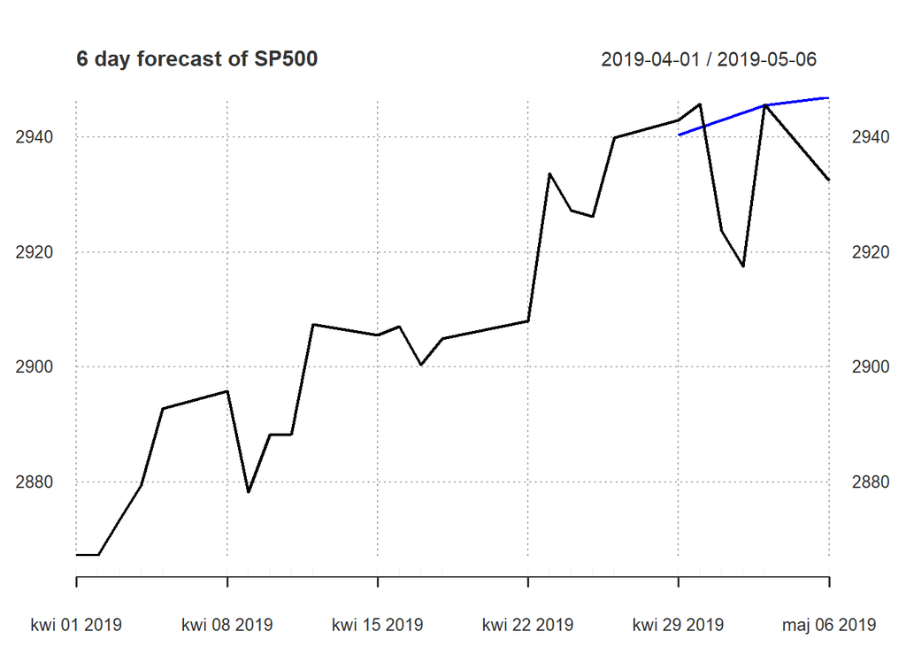

```r
plot(SP500["2019-04/", c("SP500", "SP500_fore")],
     major.ticks = "weeks",
     grid.ticks.on = "weeks",
     grid.ticks.lty = 3,
     main = "6 day forecast of SP500",
     col = c("black", "blue"))
```

# Exercises 12

Download a selected time series from Yahoo! Finance and calculate returns for a selected period.

## Exercise 12.1

Examine the existence of:

1. asymmetry in the conditional variance function (EGARCH),
2. risk premium in the log-residuals (GARCH-m),
3. t-Student distribution as an alternative to normal distribution of the error term (GARCH-t).

## Exercise 12.2

Find out which model is the best and use it to forecast a mean of the series for the next 5 periods.